# FigureYa131CMap_update

# Academic Citation

If you use this code in your work or research, we kindly request that you cite our publication:

Xiaofan Lu, et al. (2025). FigureYa: A Standardized Visualization Framework for Enhancing Biomedical Data Interpretation and Research Efficiency. iMetaMed. https://doi.org/10.1002/imm3.70005

# 需求描述

# Description of the Task

药物分析，Connectivity map(CMap)分析鉴定能够靶向干性特征的潜在化合物/抑制剂，重复出下图 Drug analysis: Connectivity map (CMap) analysis identifies potential compounds/inhibitors that can target stemness features. Reproduce the figure below.

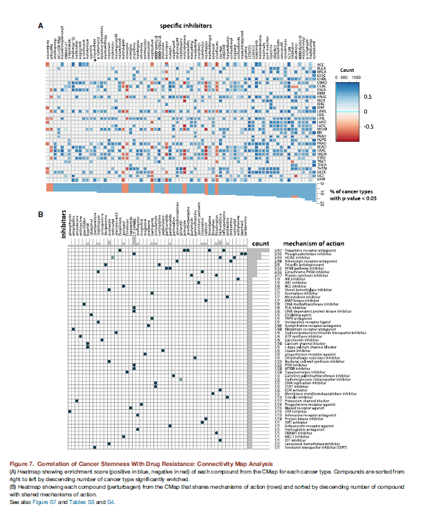

出自https://www.sciencedirect.com/science/article/pii/S0092867418303581?via%3Dihub#app2 Fromhttps://www.sciencedirect.com/science/article/pii/S0092867418303581?via%3Dihub#app2

Figure 7. Correlation of cancer stemness with drug resistance – Connectivity map analysis (A) Heatmap showing enrichment score (positive in blue, negative in red) of each compound from the CMap for each cancer type. Compounds sorted from right to left by descending number of cancer type significantly enriched. (B) Heatmap showing each compound (perturbagen) from the CMap that share Mechanism of actions (rows). Sorted by descending number of compound with shared mechanism of actions. See also Figure S7 and Tables S3 and S4.

# 应用场景

Application Scenario

任何感兴趣的差异基因都可以用CMap分析得到可能的靶向药物，关于CMap的介绍和原理可以参考[The Connectivity Map-揭示化合物，基因和疾病状态的功能联系](https://mp.weixin.qq.com/s/N0ZvANnWsbBB3XJpSr1j1g). Any differentially expressed genes of interest can be used for CMap analysis to identify possible targeted drugs. For an introduction to CMap and its principles, refer to The Connectivity Map - Revealing functional links between compounds, genes, and disease states. (https://mp.weixin.qq.com/s/N0ZvANnWsbBB3XJpSr1j1g).

[CMap build 02](https://portals.broadinstitute.org/cmap/)包含~1,300小分子化合物处理的Affymetrix芯片数据，目前还可以使用但是已经不更新和维护了。考虑到新版的[clue.io](https://clue.io/)query只能上传最多150个上调和下调差异基因，而CMap build 02版本可以总共上传1000个基因（上调和下调基因总和不超过1000个基因）。 [CMap build 02](https://portals.broadinstitute.org/cmap/) contains Affymetrix chip data of ~1,300 small molecule compounds. It is still available but no longer updated and maintained. Considering that the new version of [clue.io](https://clue.io/) query can only upload up to 150 up-regulated and down-regulated differentially expressed genes, while CMap build 02 can upload a total of 1,000 genes (the total number of up-regulated and down-regulated genes does not exceed 1,000 genes).

作者在查询这个步骤依旧使用的是CMap build 02. The author still uses CMap build 02 for this query step.

而在分析mechanism of actions (MoA)和drug-target部分则选用的是[CLUE](https://clue.io/)，对感兴趣的小分子进行MoA药物作用机制分析，探索其共同的内在作用机制。 In the analysis of mechanism of actions (MoA) and drug-target, [CLUE](https://clue.io/) is used to perform MoA drug action mechanism analysis on the small molecules of interest and explore their common intrinsic mechanisms of action.

# 环境设置

# Environment Setup

Install packages using domestic mirrors

```r
source("install_dependencies.R")
```

```
## Starting R package installation...
## ===========================================
##
## Installing CRAN packages...
## Package already installed: plyr
## Package already installed: tidyverse
## Package already installed: xlsx
## Package already installed: ComplexHeatmap
## Package already installed: circlize
##
## Installing Bioconductor packages...
## Package already installed: GEOquery
##
## ===========================================
## Package installation completed!
## You can now run your R scripts in this directory.
```

```r
library(xlsx)
library(tidyverse)
library(GEOquery)
library(plyr)
library(circlize)
library(ComplexHeatmap)

options(java.parameters = "-Xmx8000m")
Sys.setenv(LANGUAGE = "en") #显示英文报错信息 Display English error message
options(stringsAsFactors = FALSE) #禁止chr转成factor Disable conversion of chr to factor
```

# PART 1: 重复出文章Figure 7A

# PART 1: Repeat Figure 7A

## 生成CMap输入文件

## Generate Input Files for CMap

pandif_mRNAsi.xlsx，这里用的是TCGA泛癌数据根据mRNAsi指标高低求出的差异基因。出自例文附件Table S3https://ars.els-cdn.com/content/image/1-s2.0-S0092867418303581-mmc3.xlsx，你也可以用任何你感兴趣的差异基因作为输入。 pandif_mRNAsi.xlsx, here we use the differentially expressed genes from the TCGA pan-cancer data according to the mRNAsi index. From the example text attachment Table S3 https://ars.els-cdn.com/content/image/1-s2.0-S0092867418303581-mmc3.xlsx, you can also use any differentially expressed genes you are interested in as input.

```r
#CMap要求输入基因是GPL96 platform ID的形式
#Refer to the CMap query_update.docx in the same folder for detailed operation steps. Use ACC as an example.
GPL96 <- getGEO("GPL96", destdir = getwd())
GPL96 <- Table(GPL96)[, c("ID", "Gene Symbol")]

pan_n <- 33
pancancertype <- c("ACC", "BLCA", "BRCA", "CESC", "CHOL", "COAD", "DLBC", "ESCA", "GBM", "HNSC",
                   "KICH", "KIRC", "KIRP", "LAML", "LGG", "LIHC", "LUAD", "LUSC", "MESO", "OV",
                   "PAAD", "PCPG", "PRAD", "READ", "SARC", "SKCM", "STAD", "TGCT", "THCA", "THYM",
                   "UCEC", "UCS", "UVM")
diflist <- list()

# 读取数据
# # Read data
for (i in 1:pan_n){
  print(paste0("Load ", pancancertype[i], " differentially expressed gene data"))
  difdata <- openxlsx::read.xlsx("pandif_mRNAsi.xlsx", sheet = i, colNames = TRUE) %>%
    merge(GPL96, ., by.x = "Gene Symbol", by.y = "GeneSymbol")
  difdata$logFC <- as.numeric(difdata$logFC)
  difdata <- difdata[order(difdata$logFC, decreasing = T), ]
  diflist[[i]] <- difdata
}
```

```
## [1] "Load ACC differentially expressed gene data"
## [1] "Load BLCA differentially expressed gene data"
## [1] "Load BRCA differentially expressed gene data"
## [1] "Load CESC differentially expressed gene data"
## [1] "Load CHOL differentially expressed gene data"
## [1] "Load COAD differentially expressed gene data"
## [1] "Load DLBC differentially expressed gene data"
## [1] "Load ESCA differentially expressed gene data"
## [1] "Load GBM differentially expressed gene data"
## [1] "Load HNSC differentially expressed gene data"
## [1] "Load KICH differentially expressed gene data"
## [1] "Load KIRC differentially expressed gene data"
## [1] "Load KIRP differentially expressed gene data"
## [1] "Load LAML differentially expressed gene data"
## [1] "Load LGG differentially expressed gene data"
```

[output cut: 18 more lines]

```r
names(diflist) <- pancancertype

# 输出grp文件(one gene per line)
if (!file.exists("./grpfile")){
  dir.create("./grpfile")
}
for (i in 1:pan_n){
  print(paste0(pancancertype[i], " processing"))
  tmpdata <- diflist[[i]]
  tmp_updata <- tmpdata[tmpdata$logFC > 0, ]
  tmp_downdata <- tmpdata[tmpdata$logFC < 0, ]
  # 选择差异最大的前500个基因
  # Select the top 500 genes with the largest differences
  if (nrow(tmp_updata) > 500){
    top500up <- tmp_updata[, "ID"][1:500]
  } else {top500up <- tmp_updata[, "ID"]}

  if (nrow(tmp_downdata) > 500){
    top500down <- rev(tmp_downdata[, "ID"])[1:500]
  } else {top500down <- rev(tmp_downdata[, "ID"])}
  # 写成grp格式文件
  # Written in grp format
  write.table(top500up, paste0("grpfile/", pancancertype[i], "_up500.grp"),
              row.names = F, sep = "\t", quote = F, col.names = F)
  write.table(top500down, paste0("grpfile/", pancancertype[i], "_down500.grp"),
              row.names = F, sep = "\t", quote = F, col.names = F)
}
```

```
## [1] "ACC processing"
## [1] "BLCA processing"
## [1] "BRCA processing"
## [1] "CESC processing"
## [1] "CHOL processing"
## [1] "COAD processing"
## [1] "DLBC processing"
## [1] "ESCA processing"
## [1] "GBM processing"
## [1] "HNSC processing"
## [1] "KICH processing"
## [1] "KIRC processing"
## [1] "KIRP processing"
## [1] "LAML processing"
## [1] "LGG processing"
```

[output cut: 18 more lines]

## CMap query

需要用到CMap，具体操作方法见同一文件夹下的**CMap query_update.docx**文件，这里以ACC为例，获得ACC_CMap_result.xls。 CMap is needed. For specific operation methods, see the **CMap query_update.docx** file in the same folder. Here, ACC is taken as an example to obtain ACC_CMap_result.xls.

把按照操作文档运行的结果ACC_CMap_result.xls跟文章提供附件结果做对比。Connectivity_Map_Output.xlsx出自例文附件Table S4，https://ars.els-cdn.com/content/image/1-s2.0-S0092867418303581-mmc4.xlsx。 Compare the result ACC_CMap_result.xls of running according to the operation document with the result provided in the article. Connectivity_Map_Output.xlsx is from Table S4 of the example article, https://ars.els-cdn.com/content/image/1-s2.0-S0092867418303581-mmc4.xlsx.

```r
# 按操作文档得到的结果
# According to the procedure described in the operation manual
ACC_CMap_result <- xlsx::read.xlsx("ACC_CMap_result.xls", sheetIndex = 1, header = T)
ACC_CMap_result$p <- as.numeric(ACC_CMap_result$p)
# p < 0.05 筛选具有统计学意义的化合物
# Filter compounds with statistically significant p-values (p < 0.05)
ACC_CMap_sig <- na.omit(ACC_CMap_result)
ACC_CMap_sig <- ACC_CMap_sig[ACC_CMap_sig$p < 0.05, ]
dim(ACC_CMap_sig)
```

```
## [1] 136   8
```

```r
# 例文的结果
# Result from the example article
ACC_CMap_paper <- openxlsx::read.xlsx("Connectivity_Map_Output.xlsx", sheet = 1, colNames = T) #读取sheet1 ACC
# Read sheet 1 (ACC) from the Connectivity Map Output file
dim(ACC_CMap_paper)
```

```
## [1] 140   8
```

```r
# 两个结果的交集
# Intersection between two results
camp_inter <- length(intersect(ACC_CMap_sig$cmap.name, ACC_CMap_paper$cmap.name))
camp_inter
```

```
## [1] 85
```

```r
paper_cmap <- ACC_CMap_result[ACC_CMap_result$cmap.name %in% ACC_CMap_paper$cmap.name, ]
head(paper_cmap)
```

```
##   rank       cmap.name   mean  n enrichment     p specificity percent.non.null
## 1    1       LY-294002 -0.342 61     -0.354 0e+00      0.2331               67
## 2    2         GW-8510 -0.762  4     -0.932 2e-05       0.084              100
## 3    3    0175029-0000 -0.742  6     -0.852 2e-05      0.0282              100
## 4    4    8-azaguanine -0.864  4     -0.922 4e-05           0              100
## 5    5   thioguanosine -0.844  4     -0.921 6e-05       0.007              100
## 6    6 podophyllotoxin  0.738  4      0.912 6e-05      0.0143              100
```

# 虽然跟原文提供的结果不是完全一致。分析的原因可能是在处理输入差异基因这一步骤上，文章说在匹配gpl96探针数据FC排序之后去掉重复的ID。这一步骤我是多个探针匹配同一个基因只保留一个探针。还试过删除掉多个探针匹配一个基因的全部探针以及保留全部的unique探针。结果都不能达到完全一致。